# **Reproducible Research: Peer Assessment 1**

Bilmar Fernando H. H.

12 de agosto de 2015

## **Loading and preprocessing the data**

Show any code that is needed to Load the data (i.e. `read.csv()`)  
Process/transform the data (if necessary) into a format suitable for your analysis

*Lubridate’s wday function can occupy in the Weekday’s full names as ordered factor variables.*  
*Create a column of these days of the week for each date for subsetting.*

```r
activity <- read.csv("activity.csv", colClasses = c("numeric", "character", "numeric"))
activity$date <- as.Date(activity$date)
activity$Weekday <- wday(activity$date, label = TRUE, abbr = FALSE)
head(activity)
```

```
##   steps       date interval Weekday
## 1    NA 2012-10-01        0  Monday
## 2    NA 2012-10-01        5  Monday
## 3    NA 2012-10-01       10  Monday
## 4    NA 2012-10-01       15  Monday
## 5    NA 2012-10-01       20  Monday
## 6    NA 2012-10-01       25  Monday
```

## **What is mean total number of steps taken per day?**

For this part of the assignment, you can ignore the missing values in the dataset.

**1.-** Calculate the total number of steps taken per day

```r
totalStep <- aggregate(steps ~ date, data = activity, sum, na.rm = TRUE)
print(totalStep)
```

```
##          date steps
## 1  2012-10-02   126
## 2  2012-10-03 11352
## 3  2012-10-04 12116
## 4  2012-10-05 13294
## 5  2012-10-06 15420
## 6  2012-10-07 11015
## 7  2012-10-09 12811
## 8  2012-10-10  9900
## 9  2012-10-11 10304
## 10 2012-10-12 17382
## 11 2012-10-13 12426
## 12 2012-10-14 15098
## 13 2012-10-15 10139
## 14 2012-10-16 15084
```

[output cut: 39 more lines]

Makes a histogram of the total number of steps taken each day

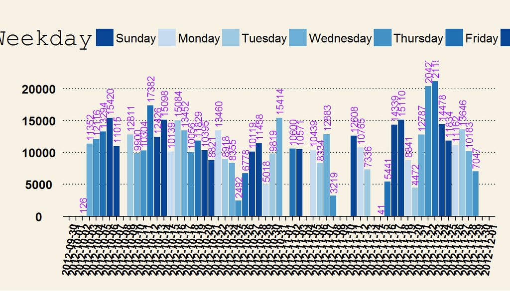

```r
par(mar = c(5, 4, 1, 1), las = 1)
make.sums.ggplot <- function(activity.dataframe, RBrewers.colors = "Blues"){
  activity.sums <- activity.dataframe %>%
  group_by(date, Weekday) %>%
  summarise(totalStep = sum(steps))
  my.cols <- brewer.pal(7, RBrewers.colors)
  my.cols[1] <- my.cols[7]
  max.sum <- max(activity.sums$totalStep, na.rm = TRUE)
  ggplot(activity.sums, aes(x = date, y = totalStep, fill = Weekday)) + geom_bar(stat = "identity") +
    scale_x_date(breaks = "1 day", limits = as.Date(c('2012-10-02','2012-11-29'))) +
    theme_wsj() +
    theme(axis.text.x  = element_text(size = 10, angle = 80, colour = "black", vjust = 1, hjust = 1)) +
    scale_fill_manual(values = my.cols) +
    geom_text(aes(x = date, y = totalStep, label = totalStep, angle  = 90, size = 8,
                  hjust = -0.1), color = "purple", show_guide  = F) +
    coord_cartesian(ylim = c(0, max.sum*1.15)) +
    ylab("Total Steps by Day") +
    xlab(NULL)
}
make.sums.ggplot(activity, "Blues")
```

**2.-** Calculate and report the mean and median of the total number of steps taken per day

```r
mean(totalStep$steps)
```

```
## [1] 10766.19
```

```r
median(totalStep$steps)
```

```
## [1] 10765
```

## **What is the average daily activity pattern?**

**1.-** Make a time series plot (i.e. `type = “l”`) of the 5-minute interval (x-axis) and the average number of steps taken, averaged across all days (y-axis)

```r
time_series <- tapply(activity$steps, activity$interval, mean, na.rm = TRUE)
print(time_series)
```

```
##           0           5          10          15          20          25
##   1.7169811   0.3396226   0.1320755   0.1509434   0.0754717   2.0943396
##          30          35          40          45          50          55
##   0.5283019   0.8679245   0.0000000   1.4716981   0.3018868   0.1320755
##         100         105         110         115         120         125
##   0.3207547   0.6792453   0.1509434   0.3396226   0.0000000   1.1132075
##         130         135         140         145         150         155
##   1.8301887   0.1698113   0.1698113   0.3773585   0.2641509   0.0000000
##         200         205         210         215         220         225
##   0.0000000   0.0000000   1.1320755   0.0000000   0.0000000   0.1320755
##         230         235         240         245         250         255
##   0.0000000   0.2264151   0.0000000   0.0000000   1.5471698   0.9433962
##         300         305         310         315         320         325
##   0.0000000   0.0000000   0.0000000   0.0000000   0.2075472   0.6226415
##         330         335         340         345         350         355
##   1.6226415   0.5849057   0.4905660   0.0754717   0.0000000   0.0000000
##         400         405         410         415         420         425
##   1.1886792   0.9433962   2.5660377   0.0000000   0.3396226   0.3584906
##         430         435         440         445         450         455
##   4.1132075   0.6603774   3.4905660   0.8301887   3.1132075   1.1132075
##         500         505         510         515         520         525
##   0.0000000   1.5660377   3.0000000   2.2452830   3.3207547   2.9622642
##         530         535         540         545         550         555
##   2.0943396   6.0566038  16.0188679  18.3396226  39.4528302  44.4905660
##         600         605         610         615         620         625
##  31.4905660  49.2641509  53.7735849  63.4528302  49.9622642  47.0754717
##         630         635         640         645         650         655
##  52.1509434  39.3396226  44.0188679  44.1698113  37.3584906  49.0377358
##         700         705         710         715         720         725
##  43.8113208  44.3773585  50.5094340  54.5094340  49.9245283  50.9811321
##         730         735         740         745         750         755
##  55.6792453  44.3207547  52.2641509  69.5471698  57.8490566  56.1509434
##         800         805         810         815         820         825
##  73.3773585  68.2075472 129.4339623 157.5283019 171.1509434 155.3962264
##         830         835         840         845         850         855
## 177.3018868 206.1698113 195.9245283 179.5660377 183.3962264 167.0188679
##         900         905         910         915         920         925
## 143.4528302 124.0377358 109.1132075 108.1132075 103.7169811  95.9622642
##         930         935         940         945         950         955
##  66.2075472  45.2264151  24.7924528  38.7547170  34.9811321  21.0566038
```

[output cut: 41 more lines]

```
##  19.6226415  19.0188679  19.3396226  33.3396226  26.8113208  21.1698113
##        2030        2035        2040        2045        2050        2055
##  27.3018868  21.3396226  19.5471698  21.3207547  32.3018868  20.1509434
##        2100        2105        2110        2115        2120        2125
##  15.9433962  17.2264151  23.4528302  19.2452830  12.4528302   8.0188679
##        2130        2135        2140        2145        2150        2155
##  14.6603774  16.3018868   8.6792453   7.7924528   8.1320755   2.6226415
##        2200        2205        2210        2215        2220        2225
##   1.4528302   3.6792453   4.8113208   8.5094340   7.0754717   8.6981132
##        2230        2235        2240        2245        2250        2255
##   9.7547170   2.2075472   0.3207547   0.1132075   1.6037736   4.6037736
##        2300        2305        2310        2315        2320        2325
##   3.3018868   2.8490566   0.0000000   0.8301887   0.9622642   1.5849057
##        2330        2335        2340        2345        2350        2355
##   2.6037736   4.6981132   3.3018868   0.6415094   0.2264151   1.0754717
```

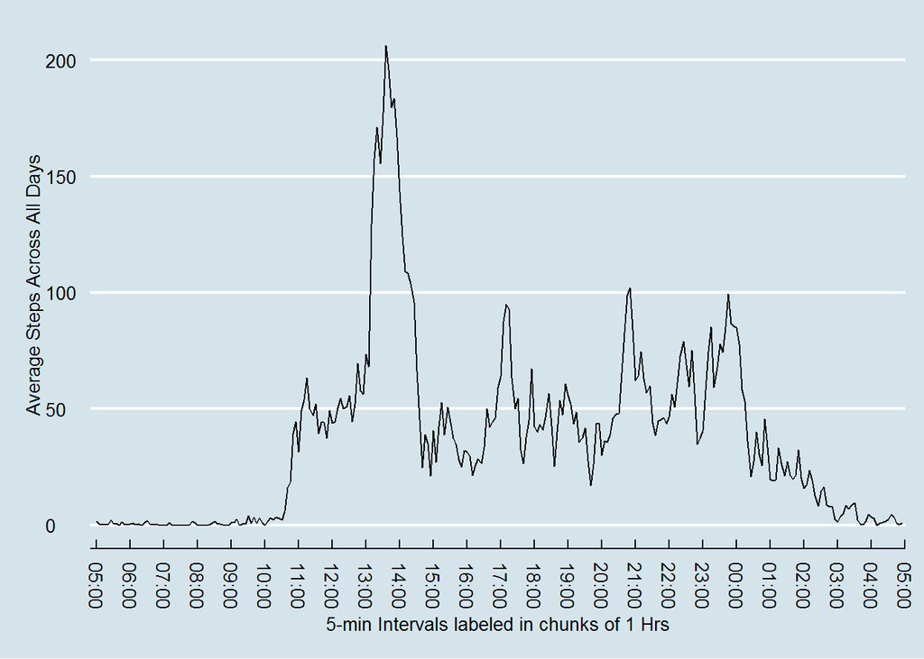

```r
activity$Interval <- as.POSIXct(strptime(sprintf("%04d", activity$interval), "%H%M"))
make.max.interval.ggplot <- function(activity.dataframe){
  activity.intervals <- activity.dataframe %>%
    group_by(Interval) %>%
    summarise(Average = mean(steps, na.rm = TRUE)) %>%
    arrange(Interval)
  max.activity <- activity.intervals[which.max(activity.intervals$Average),]
  max.interval <<- max.activity$Interval[1]
  max.average <<- round(max.activity$Average[1], 2)
  ggplot(activity.intervals, aes(x = Interval, y = Average)) +
    geom_line() +
    theme_economist() +
    theme(axis.text.x=element_text(angle=270, hjust=1, vjust=0.5, size = 10)) +
    scale_x_datetime(breaks = date_breaks("60 min"), labels = date_format("%H:%M"),
                     limits = c(activity.intervals$Interval[12], activity.intervals$Interval[286-10])) +
    ylab("Average Steps Across All Days") +
    xlab("5-min Intervals labeled in chunks of 1 Hrs")
}
make.max.interval.ggplot(activity)
```

## **Imputing missing values**

*Note that there are a number of days/intervals where there are missing values (coded as `NA`). The presence of missing days may introduce bias into some calculations or summaries of the data.*

**1.-** Calculate and report the total number of missing values in the dataset (i.e. the total number of rows with `NA`s)

```r
summary(activity)
```

```
##      steps             date               interval           Weekday
##  Min.   :  0.00   Min.   :2012-10-01   Min.   :   0.0   Sunday   :2304
##  1st Qu.:  0.00   1st Qu.:2012-10-16   1st Qu.: 588.8   Monday   :2592
##  Median :  0.00   Median :2012-10-31   Median :1177.5   Tuesday  :2592
##  Mean   : 37.38   Mean   :2012-10-31   Mean   :1177.5   Wednesday:2592
##  3rd Qu.: 12.00   3rd Qu.:2012-11-15   3rd Qu.:1766.2   Thursday :2592
##  Max.   :806.00   Max.   :2012-11-30   Max.   :2355.0   Friday   :2592
##  NA's   :2304                                           Saturday :2304
##     Interval
##  Min.   :2015-08-14 00:00:00
##  1st Qu.:2015-08-14 05:58:45
##  Median :2015-08-14 11:57:30
##  Mean   :2015-08-14 11:57:30
##  3rd Qu.:2015-08-14 17:56:15
##  Max.   :2015-08-14 23:55:00
##
```

```r
NA.activity <- subset(activity, !complete.cases(activity))
table(NA.activity$date)
```

```
##
## 2012-10-01 2012-10-08 2012-11-01 2012-11-04 2012-11-09 2012-11-10
##        288        288        288        288        288        288
## 2012-11-14 2012-11-30
##        288        288
```

**2.-** Devise a strategy for occupying in all of the missing values in the dataset. The strategy does not need to be sophisticated. *For example, you could use the mean/median for that day, or the mean for that 5-minute interval, etc.*

```r
interval.summary <- function(activity_frame, interval_string = "all"){
  activity_frame$temp_time <- format(activity_frame$Interval, "%H:%M")
  if (class(interval_string) != "character") {
    stop("Please enter an interval as a string.")
    }
  if (!(interval_string %in% c( activity_frame$temp_time, "all" ) ) ) {
    stop("Please enter a 5 minute interval in the form of 00:00")
    }
  output <- activity_frame %>%
    group_by(temp_time, Weekday) %>%
    summarise(Average = mean(steps, na.rm = TRUE))
  if (interval_string == "all") {
    return(output)
    } else {
      output<- output %>%
        filter(temp_time == interval_string)
      return(output)
      }
  }
interval.summary(activity, "08:05")
```

```
## Source: local data frame [7 x 3]
## Groups: temp_time
##
##   temp_time   Weekday   Average
## 1     08:05    Sunday  80.85714
## 2     08:05    Monday  42.00000
## 3     08:05   Tuesday  89.11111
## 4     08:05 Wednesday 134.37500
## 5     08:05  Thursday  49.25000
## 6     08:05    Friday  37.71429
## 7     08:05  Saturday  31.42857
```

**3.-** Create a new dataset that is equal to the original dataset but with the missing data occupyed in.

```r
imputed <- activity %>%
  mutate(steps = as.numeric(steps)) %>%
  group_by(Interval, Weekday) %>%
  mutate(steps = ifelse(is.na(steps), mean(steps, na.rm = TRUE), steps)) %>%
  mutate(steps = round(steps, 2))
```

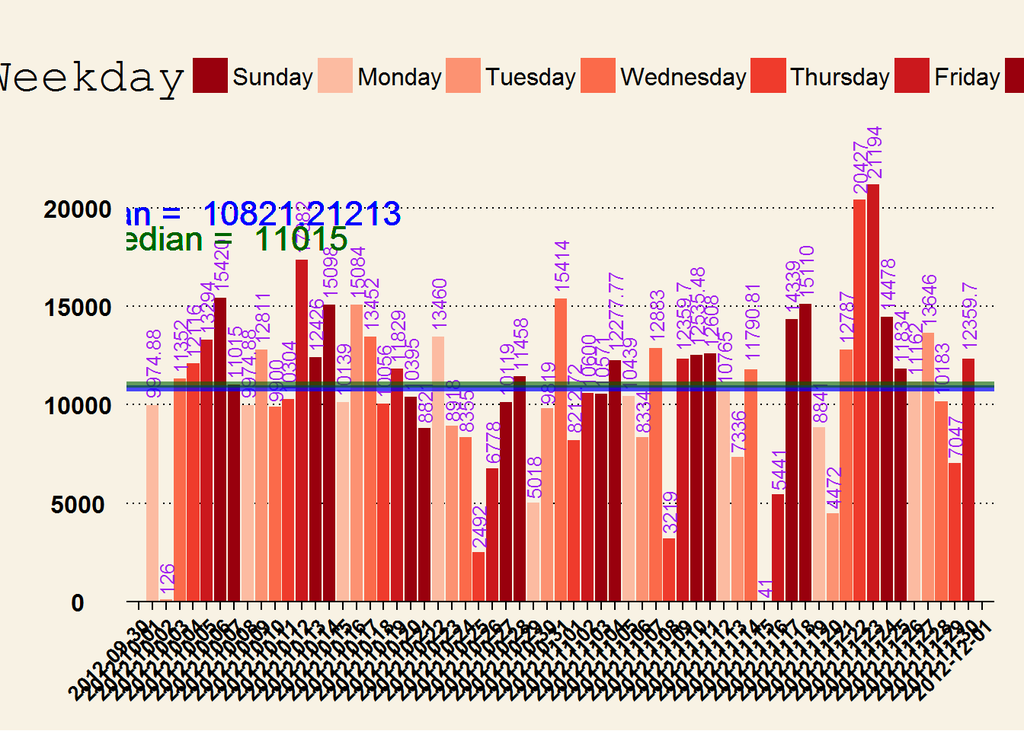

```r
make2.sums.ggplot <- function(activity.dataframe, RBrewers.colors = "Reds"){
  activity.sums <- activity.dataframe %>%
  group_by(date, Weekday) %>%
  summarise(totalStep = sum(steps))
  my.cols <- brewer.pal(7, RBrewers.colors)
  my.cols[1] <- my.cols[7]
  max.sum <- max(activity.sums$totalStep, na.rm = TRUE)
  ggplot(activity.sums, aes(x = date, y = totalStep, fill = Weekday)) + geom_bar(stat = "identity") +
    scale_x_date(breaks = "1 day", limits = as.Date(c('2012-10-02','2012-11-29'))) +
    theme_wsj() +
    theme(axis.text.x  = element_text(size = 10, angle = 45, colour = "black", vjust = 1, hjust = 1)) +
    scale_fill_manual(values = my.cols) +
    geom_text(aes(x = date, y = totalStep, label = totalStep, angle  = 90, size = 8,
                  hjust = -0.1), color = "purple", show_guide  = F) +
    coord_cartesian(ylim = c(0, max.sum*1.15)) +
    geom_hline(aes ( yintercept = mean(totalStep, na.rm = TRUE)),
               color = "blue", size = 1.5, alpha = .70) +
    geom_hline(aes ( yintercept = median(totalStep, na.rm = TRUE)),
               color = "darkgreen",size = 1.5, alpha = .60) +
    geom_text(aes(label = paste("Mean = ", round(mean(totalStep, na.rm = TRUE), 5)),
                  x = as.Date('2012-10-07'), y = 19800), color = "blue", size = 6) +
    geom_text(aes(label = paste("Median = ", round(median(totalStep, na.rm = TRUE), 5)),
                  x = as.Date('2012-10-06'), y = 18500), color = "darkgreen", size = 6) +
    ylab("Total Steps by Day") +
    xlab(NULL)
}
make2.sums.ggplot(imputed, "Reds")
```

# **Are there differences in activity patterns between weekdays and weekends?**

**1.-** Create a new factor variable in the dataset with two levels – “weekday” and “weekend” indicating whether a given date is a weekday or weekend day.

```r
imputed <- activity %>%
mutate(Weekend = ifelse(Weekday %in% c("Saturday", "Sunday"), "Weekend", "Weekday"))
table(imputed$Weekend, imputed$Weekday)
```

```
##
##           Sunday Monday Tuesday Wednesday Thursday Friday Saturday
##   Weekday      0   2592    2592      2592     2592   2592        0
##   Weekend   2304      0       0         0        0      0     2304
```

**2.-** Make a panel plot containing a time series plot (i.e. `type = “l”`) of the 5-minute interval (x-axis) and the average number of steps taken, averaged across all weekday days or weekend days (y-axis). See the README file in the GitHub repository to see an example of what this plot should look like using simulated data.

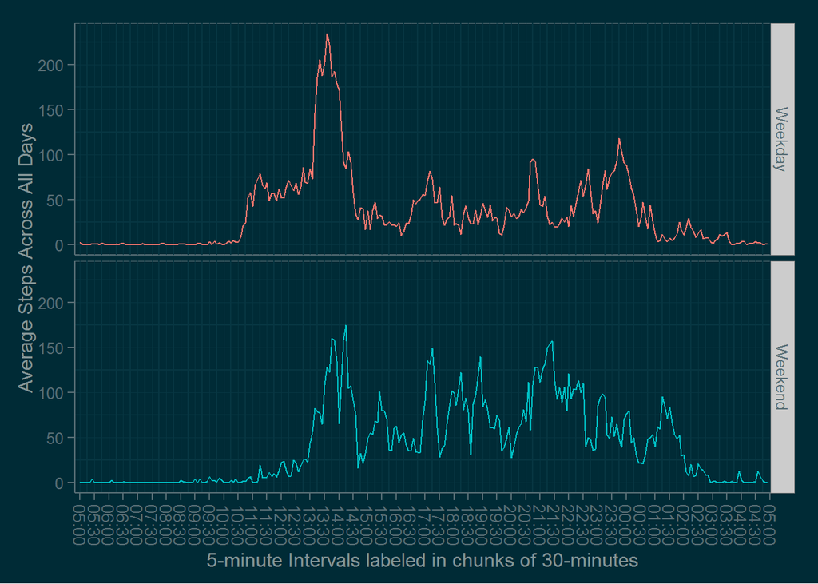

```r
make.Weekend.ggplot <- function(activity.dataframe){
  activity.intervals <- activity.dataframe %>%
    group_by(Weekend, Interval) %>%
    summarise(Average = mean(steps, na.rm = TRUE))
  ggplot(activity.intervals, aes(x = Interval, y = Average, group = Weekend, color = Weekend)) +
    theme_solarized(light = FALSE) +
    geom_line() +
    facet_grid(Weekend~.) +
    theme(axis.text.x=element_text(angle=270,hjust=1,vjust=0.5, size = 10)) +
    scale_x_datetime(breaks = date_breaks("30 mins"), labels = date_format("%H:%M"),
                     limits = c(activity.intervals$Interval[12], activity.intervals$Interval[286-10])) +
    ylab("Average Steps Across All Days") +
    xlab("5-minute Intervals labeled in chunks of 30-minutes") +
    theme(legend.position="none")
}
make.Weekend.ggplot(imputed)
```